# Time Series: A First Course with Bootstrap Starter

# Lesson 12-4: Model-based Bootstrap

- We want to extend the bootstrap idea to the case of time series data.
- We don’t want to assume i.i.d. anymore, because time series data have serial dependence.

## Paradigm 12.4.2. Bootstrapping an AR(1) Model

- Suppose $\{ X_t \}$ is a stationary AR(1) process with i.i.d. inputs with cdf $G$:
  $$X_t - \phi X_{t-1} = \epsilon_t,$$
  where $\epsilon_t \sim \mbox{i.i.d.} G$.
- Suppose we want to estimate the cdf of $\widehat{\phi} - \phi$, where $\widehat{\phi}$ is the Yule-Walker estimator.
- So for any $x$, we want a bootstrap estimate of $\zeta = {\mathbb P} [ \widehat{\phi} - \phi \leq x]$.
- We compute residuals
  $$e_t = X_t - \widehat{\phi} X_{t-1},$$
  and use these as proxies for $\epsilon_t$.
- Center the residuals by their sample mean, and let $\widehat{G}$ be their edf.
1. For large $M$ simulate
   $$\begin{align*}
   & \epsilon_1^{*(1)}, \ldots, \epsilon_n^{*(1)} \sim \mbox{i.i.d.}
   \widehat{G} \\
   & \epsilon_1^{*(2)}, \ldots, \epsilon_n^{*(2)} \sim \mbox{i.i.d.}
   \widehat{G} \\
   & \ldots \\
   & \epsilon_1^{*(M)}, \ldots, \epsilon_n^{*(M)} \sim \mbox{i.i.d.}
   \widehat{G}.
   \end{align*}$$
2. For $1 \leq j \leq M$ construct
   $$X_t^{*(j)} = \widehat{\phi} X_{t-1}^{*(j)} + \epsilon_t^{*(j)}$$
   for $1 \leq t \leq n$.
3. Compute $\widehat{\phi}^{*(j)}$ from the *pseudo-sample* $X_1^{*(j)}, \ldots, X_n^{*(j)}$.
4. Our bootstrap estimator of $\zeta$ is
   $$\frac{1}{M} \sum_{j=1}^M 1_{ \{ \widehat{\phi}^{*(j)} - \widehat{\phi}
   \leq x \}}.$$

## Example 12.4.3. Bootstrap for the AR(1) Coefficient of U.S. Population Growth

- For the U.S. Population time series $\{ Y_t \}$, we can also consider fitting an AR(1) model to first differences.

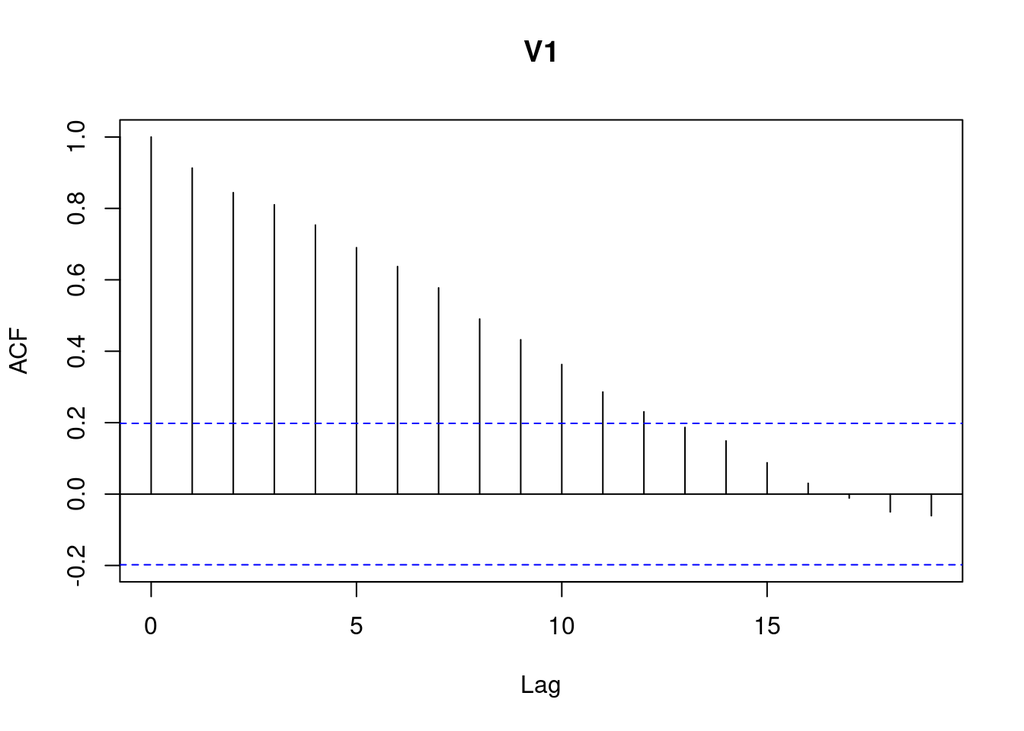

```r
pop <- read.table("USpop.dat")
pop <- ts(pop, start = 1901)
pop.diff <- diff(pop)*10^(-6)
acf(pop.diff)
```

- Let $X_t = (1-B) Y_t$, and consider the AR(1) model for $\{ X_t\}$.
- Suppose we want to estimate the cdf of $\widehat{\phi} - \phi$ using the bootstrap with $M = 10^5$.

```r
n <- length(pop.diff)
kappa.hat <- pacf(pop.diff,lag=n-1,plot=FALSE)$acf[,,1]
pop.ar1 <- kappa.hat[1]
pop.resids <- pop.diff[2:n] - pop.ar1*pop.diff[1:(n-1)]
pop.resids <- pop.resids - mean(pop.resids)
pop.edf <- sort(pop.resids)

monte.roots <- NULL
Monte <- 100000
for(i in 1:Monte)
{
    monte.resids <- sample(pop.edf,size=n,replace=TRUE)
    init.value <- sample(pop.diff,size=1)
    monte.sample <- filter(monte.resids,pop.ar1,method="recursive",init=init.value)
    monte.root <- pacf(monte.sample,lag=n-1,plot=FALSE)$acf[,,1][1] - pop.ar1
    monte.roots <- c(monte.roots,monte.root)
}
# hist(monte.roots)
interval <- c(sort(monte.roots)[floor(.025*Monte)],sort(monte.roots)[floor(.975*Monte)])
```

- The AR(1) coefficient is estimated to be 0.9130219.
- The $95 \%$ confidence interval based on the bootstrap is [0.8836624,1.0546415].
- We plot the bootstrap edf.

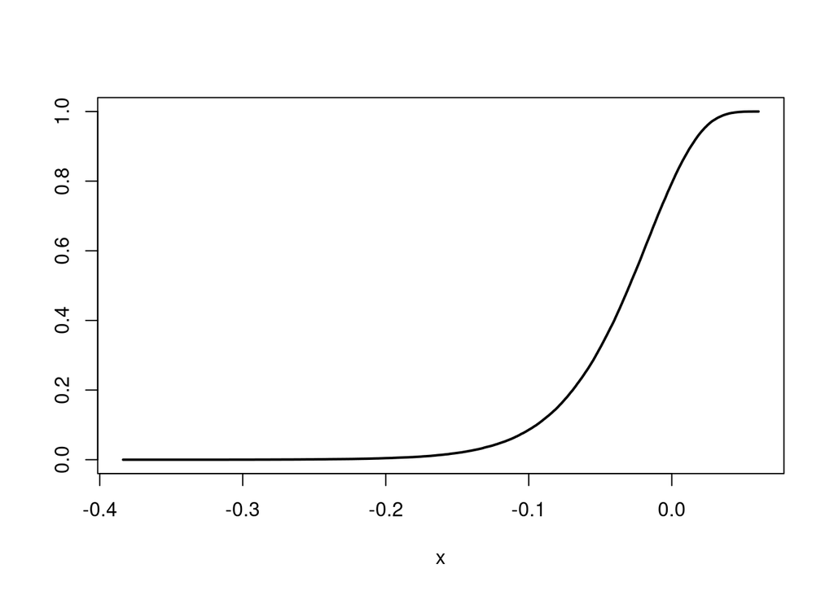

```r
plot(sort(monte.roots),seq(1,Monte)/Monte,type="l",xlab="x",ylab="",lwd=2)
```

## Paradigm 12.4.7. Bootstrap and the Model-Free Principle

- Using a transformation (instead of a model) that produces i.i.d. residuals from the data process is called the *model-free principle*.
- So to do a time series bootstrap, we should seek such a transformation, bootstrap the residuals, reconstruct the process, and evaluate the statistic on the pseudo-samples.
- Suppose there exists an invertible transformation $\Pi$ such that $\underline{\epsilon} = \Pi (\underline{X})$ is a vector of i.i.d. components, where $\underline{X} = {[ X_1, \ldots, X_n ]}^{\prime}$.
- Let $G$ denote the cdf of $\epsilon_t$.
- Suppose we have a statistic $\widehat{\theta}_n$ and we want the cdf $\zeta = {\mathbb P} [ \widehat{\theta}_n - \theta \leq x]$.
- Compute the residuals, and estimate $G$ via the residual edf $\widehat{G}$.
- Then the *Model-free bootstrap* is:
1. For large $M$ simulate
   $$\begin{align*}
   & \epsilon_1^{*(1)}, \ldots, \epsilon_n^{*(1)} \sim \mbox{i.i.d.}
   \widehat{G} \\
   & \epsilon_1^{*(2)}, \ldots, \epsilon_n^{*(2)} \sim \mbox{i.i.d.}
   \widehat{G} \\
   & \ldots \\
   & \epsilon_1^{*(M)}, \ldots, \epsilon_n^{*(M)} \sim \mbox{i.i.d.}
   \widehat{G}.
   \end{align*}$$
2. For $1 \leq j \leq M$ construct
   $$\underline{X}^{*(j)} = \Pi^{-1} [ \underline{\epsilon}^{*(j)} ].$$
3. Compute $\widehat{\theta}_n^{*(j)}$ from the *pseudo-sample* $\underline{X}^{*(j)}$.
4. Our bootstrap estimator of $\zeta$ is
   $$\frac{1}{M} \sum_{j=1}^M 1_{ \{ \widehat{\theta}_n^{*(j)} -
   \widehat{\theta} \leq x \}}.$$